# Handling dates in R

# Common examples with tabular data

## An “ideal” situation

The first table/data frame example for is from a programme I wrote which logs system resource variables for unix systems. This programme has been carefully designed to ensure the dates are logged and presented in a standard way which makes the job of handling the dates as simple as it can be.

```r
# Load file
data_system <- read.csv("data/system_logger_data.csv", stringsAsFactors = FALSE)

# Look at the top of the data
head(data_system)
```

```
##             hostname                    date  uptime cpu_percent memory_percent
## 1 dell_inspiron_5323 2016-07-15 00:00:00 UTC 5976198       11.28          14.00
## 2 dell_inspiron_5323 2016-07-15 00:01:00 UTC 5976258        1.42          13.13
## 3 dell_inspiron_5323 2016-07-15 00:02:00 UTC 5976318        1.02          12.90
## 4 dell_inspiron_5323 2016-07-15 00:03:00 UTC 5976378        1.03          12.90
## 5 dell_inspiron_5323 2016-07-15 00:04:00 UTC 5976438        1.07          12.90
## 6 dell_inspiron_5323 2016-07-15 00:05:00 UTC 5976498        1.57          12.90
```

```r
# What data types has the read.csv given the variables?
str(data_system)
```

```
## 'data.frame':    1440 obs. of  5 variables:
##  $ hostname      : chr  "dell_inspiron_5323" "dell_inspiron_5323" "dell_inspiron_5323" "dell_inspiron_5323" ...
##  $ date          : chr  "2016-07-15 00:00:00 UTC" "2016-07-15 00:01:00 UTC" "2016-07-15 00:02:00 UTC" "2016-07-15 00:03:00 UTC" ...
##  $ uptime        : int  5976198 5976258 5976318 5976378 5976438 5976498 5976558 5976618 5976678 5976738 ...
##  $ cpu_percent   : num  11.28 1.42 1.02 1.03 1.07 ...
##  $ memory_percent: num  14 13.1 12.9 12.9 12.9 ...
```

`str` (structure) shows that the `date` variable has been loaded as a character not a date but the format is in the standard `yyyy-mm-dd hh:mm:ss` format. The date also has a time-zone string which is useful to know too. The dates can be parsed simply with `ymd_hms`:

```r
# Parse dates with lubridate
data_system$date <- ymd_hms(data_system$date, tz = "UTC")

# Look at data types now
str(data_system)
```

```
## 'data.frame':    1440 obs. of  5 variables:
##  $ hostname      : chr  "dell_inspiron_5323" "dell_inspiron_5323" "dell_inspiron_5323" "dell_inspiron_5323" ...
##  $ date          : POSIXct, format: "2016-07-15 00:00:00" "2016-07-15 00:01:00" "2016-07-15 00:02:00" "2016-07-15 00:03:00" ...
##  $ uptime        : int  5976198 5976258 5976318 5976378 5976438 5976498 5976558 5976618 5976678 5976738 ...
##  $ cpu_percent   : num  11.28 1.42 1.02 1.03 1.07 ...
##  $ memory_percent: num  14 13.1 12.9 12.9 12.9 ...
```

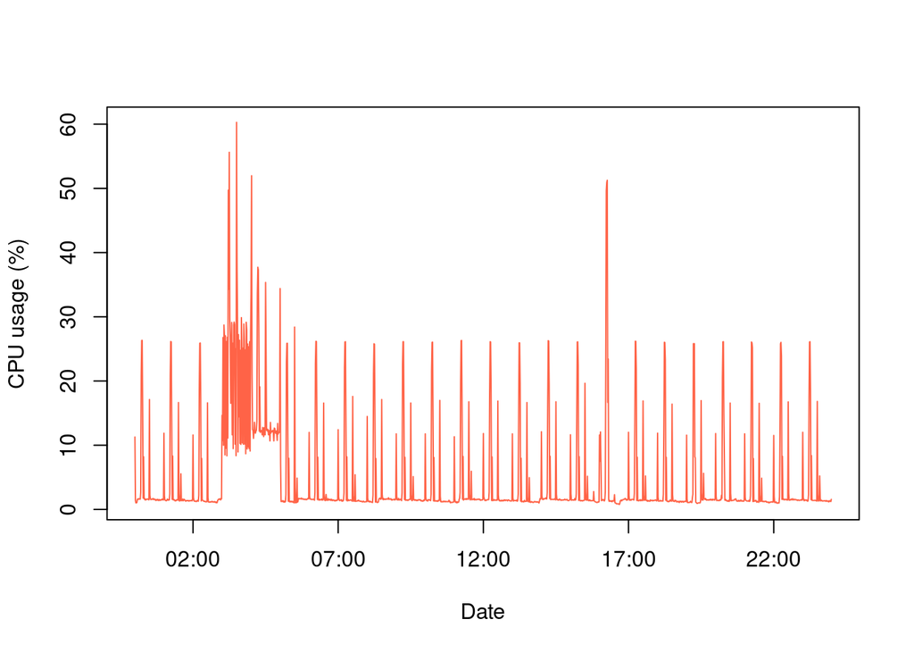

```r
# Plot
plot(data_system$date, data_system$cpu_percent, type = "l", col = "tomato",
     ylab = "CPU usage (%)", xlab = "Date")
```

Now that the data type is correct (`POSIXct`) R’s functions such as `plot` knows how to correctly deal with the variable which is shown by correct presentation and formatting of the *x*-axis and analysis can continue.

## A simple variation

```r
# Load a temperature time-series
data_temp <- read.csv("data/temperature_data.csv", stringsAsFactors = FALSE)

# Look at date format
head(data_temp$date)
```

```
## [1] "02/06/2012 00:00" "02/06/2012 00:01" "02/06/2012 00:02" "02/06/2012 00:03" "02/06/2012 00:04" "02/06/2012 00:05"
```

These data dates have the UK convention of `dd/mm/yyyy` and are also missing the seconds component. When using **lubridate** this is easy to handle. I also know that these data are from New Zealand so this is the time-zone we can use:

```r
# Parse dates with the NZ time-zone
data_temp$date <- dmy_hm(data_temp$date, tz = "Pacific/Auckland")

# Look again
head(data_temp$date)
```

```
## [1] "2012-06-02 00:00:00 NZST" "2012-06-02 00:01:00 NZST" "2012-06-02 00:02:00 NZST" "2012-06-02 00:03:00 NZST" "2012-06-02 00:04:00 NZST" "2012-06-02 00:05:00 NZST"
```

## Another simple variation

```r
# Load some weather and wind data
data_wind <- read.csv("data/wind_data.csv")

# Look at the data
head(data_wind)
```

```
##   year month day     time   ws    wd  temp   rh
## 1 2012     7  30 00:00:41 2.65  83.9 13.91 82.7
## 2 2012     7  30 00:01:41 3.49  54.9 13.92 82.6
## 3 2012     7  30 00:02:41 2.89 102.9 13.86 82.6
## 4 2012     7  30 00:03:41 3.45  43.9 13.85 82.8
## 5 2012     7  30 00:04:41 4.89  49.9 13.82 82.9
## 6 2012     7  30 00:05:41 2.35  92.9 13.87 82.8
```

The different pieces of the date are stored as separate variables (columns) in this table. This is rather easy to deal with, all these pieces just need to be joined (or concatenated) together before using `ymd_hms`. Because `ymd_hms` is not sensitive to the delimiters used, it does not really matter what character is used for separating the date pieces, in fact joining the pieces together without a separation character will work too, but here a space (`" "`) is used:

```r
# Concatenate the date pieces together
data_wind$date <- str_c(data_wind$year, data_wind$month, data_wind$day,
                        data_wind$time, sep = " ")

# Check if the Concatenation makes sense
head(data_wind$date)
```

```
## [1] "2012 7 30 00:00:41" "2012 7 30 00:01:41" "2012 7 30 00:02:41" "2012 7 30 00:03:41" "2012 7 30 00:04:41" "2012 7 30 00:05:41"
```

```r
# Parse dates
data_wind$date <- ymd_hms(data_wind$date, tz = "Pacific/Auckland")

# Check again
head(data_wind$date)
```

```
## [1] "2012-07-30 00:00:41 NZST" "2012-07-30 00:01:41 NZST" "2012-07-30 00:02:41 NZST" "2012-07-30 00:03:41 NZST" "2012-07-30 00:04:41 NZST" "2012-07-30 00:05:41 NZST"
```

The unneeded date pieces can now be dropped if desired because they have been used and no longer add any value:

```r
# Drop variables which are not needed
data_wind <- subset(data_wind, select = -c(year, month, day, time))

# Look
head(data_wind)
```

```
##     ws    wd  temp   rh                date
## 1 2.65  83.9 13.91 82.7 2012-07-30 00:00:41
## 2 3.49  54.9 13.92 82.6 2012-07-30 00:01:41
## 3 2.89 102.9 13.86 82.6 2012-07-30 00:02:41
## 4 3.45  43.9 13.85 82.8 2012-07-30 00:03:41
## 5 4.89  49.9 13.82 82.9 2012-07-30 00:04:41
## 6 2.35  92.9 13.87 82.8 2012-07-30 00:05:41
```

# Other important date functions

```r
# Base R's functions
Sys.time()
```

```
## [1] "2020-09-23 08:26:13.2 CEST"
```

```r
Sys.timezone()
```

```
## [1] "Europe/Zurich"
```

```r
Sys.Date()
```

```
## [1] "2020-09-23"
```

```r
# Same as Sys.time but has a tz argument
now()
```

```
## [1] "2020-09-23 08:26:13.2 CEST"
```

```r
now("Pacific/Auckland")
```

```
## [1] "2020-09-23 18:26:13.2 NZST"
```

```r
# Same as Sys.Date
today()
```

```
## [1] "2020-09-23"
```

## Extracting pieces of a date

```r
# Make date
data_a_parsed <- ymd_hms("2016-08-07 22:00:05", tz = "Europe/London")

year(data_a_parsed)
```

```
## [1] 2016
```

```r
month(data_a_parsed)
```

```
## [1] 8
```

```r
day(data_a_parsed)
```

```
## [1] 7
```

```r
hour(data_a_parsed)
```

```
## [1] 22
```

```r
minute(data_a_parsed)
```

```
## [1] 0
```

```r
second(data_a_parsed)
```

```
## [1] 5
```

```r
# Time-zone, length of 1
attr(data_a_parsed, "tzone")
```

```
## [1] "Europe/London"
```

```r
as.numeric(data_a_parsed)
```

```
## [1] 1470603605
```

```r
as.integer(data_a_parsed)
```

```
## [1] 1470603605
```

## Rounding dates

```r
round_date(data_a_parsed, unit = "hour")
```

```
## [1] "2016-08-07 22:00:00 BST"
```

```r
floor_date(data_a_parsed, unit = "hour")
```

```
## [1] "2016-08-07 22:00:00 BST"
```

```r
ceiling_date(data_a_parsed, unit = "hour")
```

```
## [1] "2016-08-07 23:00:00 BST"
```

```r
# Many unit options...
```

## Lubridate version used in this note

```r
packageVersion("lubridate")
```

```
## [1] '1.7.9'
```